# FitBit Data Exploration

Fadhil Umar

2023-10-10

## Import Necessary Packages

```r
library(tidyverse)
library(lubridate)
library(dplyr)
library(ggplot2)
library(tidyr)
```

## Load Data

```r
activity_daily <- read_csv("dataset/dailyActivity_merged.csv")
calories_hourly <- read_csv("dataset/hourlyCalories_merged.csv")
intensities_hourly <- read_csv("dataset/hourlyIntensities_merged.csv")
steps_hourly <- read_csv("dataset/hourlySteps_merged.csv")
sleep_daily <- read_csv("dataset/sleepDay_merged.csv")
weight_log <- read_csv("dataset/weightLogInfo_merged.csv")
```

## Data Overview

```r
summary(activity_daily)
```

```
##        Id            ActivityDate         TotalSteps    TotalDistance
##  Min.   :1.504e+09   Length:940         Min.   :    0   Min.   : 0.000
##  1st Qu.:2.320e+09   Class :character   1st Qu.: 3790   1st Qu.: 2.620
##  Median :4.445e+09   Mode  :character   Median : 7406   Median : 5.245
##  Mean   :4.855e+09                      Mean   : 7638   Mean   : 5.490
##  3rd Qu.:6.962e+09                      3rd Qu.:10727   3rd Qu.: 7.713
##  Max.   :8.878e+09                      Max.   :36019   Max.   :28.030
##  TrackerDistance  LoggedActivitiesDistance VeryActiveDistance
##  Min.   : 0.000   Min.   :0.0000           Min.   : 0.000
##  1st Qu.: 2.620   1st Qu.:0.0000           1st Qu.: 0.000
##  Median : 5.245   Median :0.0000           Median : 0.210
##  Mean   : 5.475   Mean   :0.1082           Mean   : 1.503
##  3rd Qu.: 7.710   3rd Qu.:0.0000           3rd Qu.: 2.053
##  Max.   :28.030   Max.   :4.9421           Max.   :21.920
##  ModeratelyActiveDistance LightActiveDistance SedentaryActiveDistance
##  Min.   :0.0000           Min.   : 0.000      Min.   :0.000000
##  1st Qu.:0.0000           1st Qu.: 1.945      1st Qu.:0.000000
##  Median :0.2400           Median : 3.365      Median :0.000000
##  Mean   :0.5675           Mean   : 3.341      Mean   :0.001606
##  3rd Qu.:0.8000           3rd Qu.: 4.782      3rd Qu.:0.000000
##  Max.   :6.4800           Max.   :10.710      Max.   :0.110000
##  VeryActiveMinutes FairlyActiveMinutes LightlyActiveMinutes SedentaryMinutes
##  Min.   :  0.00    Min.   :  0.00      Min.   :  0.0        Min.   :   0.0
##  1st Qu.:  0.00    1st Qu.:  0.00      1st Qu.:127.0        1st Qu.: 729.8
##  Median :  4.00    Median :  6.00      Median :199.0        Median :1057.5
##  Mean   : 21.16    Mean   : 13.56      Mean   :192.8        Mean   : 991.2
##  3rd Qu.: 32.00    3rd Qu.: 19.00      3rd Qu.:264.0        3rd Qu.:1229.5
##  Max.   :210.00    Max.   :143.00      Max.   :518.0        Max.   :1440.0
##     Calories
##  Min.   :   0
##  1st Qu.:1828
##  Median :2134
##  Mean   :2304
##  3rd Qu.:2793
##  Max.   :4900
```

```r
summary(calories_hourly)
```

```
##        Id            ActivityHour          Calories
##  Min.   :1.504e+09   Length:22099       Min.   : 42.00
##  1st Qu.:2.320e+09   Class :character   1st Qu.: 63.00
##  Median :4.445e+09   Mode  :character   Median : 83.00
##  Mean   :4.848e+09                      Mean   : 97.39
##  3rd Qu.:6.962e+09                      3rd Qu.:108.00
##  Max.   :8.878e+09                      Max.   :948.00
```

```r
summary(intensities_hourly)
```

```
##        Id            ActivityHour       TotalIntensity   AverageIntensity
##  Min.   :1.504e+09   Length:22099       Min.   :  0.00   Min.   :0.0000
##  1st Qu.:2.320e+09   Class :character   1st Qu.:  0.00   1st Qu.:0.0000
##  Median :4.445e+09   Mode  :character   Median :  3.00   Median :0.0500
##  Mean   :4.848e+09                      Mean   : 12.04   Mean   :0.2006
##  3rd Qu.:6.962e+09                      3rd Qu.: 16.00   3rd Qu.:0.2667
##  Max.   :8.878e+09                      Max.   :180.00   Max.   :3.0000
```

```r
summary(steps_hourly)
```

```
##        Id            ActivityHour         StepTotal
##  Min.   :1.504e+09   Length:22099       Min.   :    0.0
##  1st Qu.:2.320e+09   Class :character   1st Qu.:    0.0
##  Median :4.445e+09   Mode  :character   Median :   40.0
##  Mean   :4.848e+09                      Mean   :  320.2
##  3rd Qu.:6.962e+09                      3rd Qu.:  357.0
##  Max.   :8.878e+09                      Max.   :10554.0
```

```r
summary(sleep_daily)
```

```
##        Id              SleepDay         TotalSleepRecords TotalMinutesAsleep
##  Min.   :1.504e+09   Length:413         Min.   :1.000     Min.   : 58.0
##  1st Qu.:3.977e+09   Class :character   1st Qu.:1.000     1st Qu.:361.0
##  Median :4.703e+09   Mode  :character   Median :1.000     Median :433.0
##  Mean   :5.001e+09                      Mean   :1.119     Mean   :419.5
##  3rd Qu.:6.962e+09                      3rd Qu.:1.000     3rd Qu.:490.0
##  Max.   :8.792e+09                      Max.   :3.000     Max.   :796.0
##  TotalTimeInBed
##  Min.   : 61.0
##  1st Qu.:403.0
##  Median :463.0
##  Mean   :458.6
##  3rd Qu.:526.0
##  Max.   :961.0
```

```r
summary(weight_log)
```

```
##        Id                Date              WeightKg       WeightPounds
##  Min.   :1.504e+09   Length:67          Min.   : 52.60   Min.   :116.0
##  1st Qu.:6.962e+09   Class :character   1st Qu.: 61.40   1st Qu.:135.4
##  Median :6.962e+09   Mode  :character   Median : 62.50   Median :137.8
##  Mean   :7.009e+09                      Mean   : 72.04   Mean   :158.8
##  3rd Qu.:8.878e+09                      3rd Qu.: 85.05   3rd Qu.:187.5
##  Max.   :8.878e+09                      Max.   :133.50   Max.   :294.3
##
##       Fat             BMI        IsManualReport      LogId
##  Min.   :22.00   Min.   :21.45   Mode :logical   Min.   :1.460e+12
##  1st Qu.:22.75   1st Qu.:23.96   FALSE:26        1st Qu.:1.461e+12
##  Median :23.50   Median :24.39   TRUE :41        Median :1.462e+12
##  Mean   :23.50   Mean   :25.19                   Mean   :1.462e+12
##  3rd Qu.:24.25   3rd Qu.:25.56                   3rd Qu.:1.462e+12
##  Max.   :25.00   Max.   :47.54                   Max.   :1.463e+12
##  NA's   :65
```

## Data Preprocessing

Set the date column as date format and calculate time range and unique IDs in activity_daily dataframes.

```r
# Convert ActivityDate to Date format
activity_daily$ActivityDate <- as.Date(activity_daily$ActivityDate, format = "%m/%d/%Y")

# Calculate relevant statistics
num_rows <- nrow(activity_daily)
min_date <- min(activity_daily$ActivityDate)
max_date <- max(activity_daily$ActivityDate)
num_days <- as.numeric(difftime(max_date, min_date, units = "days"))+1
num_users <- length(unique(activity_daily$Id))

# Print the information
print(paste("There are", num_rows, "rows"))
```

```
## [1] "There are 940 rows"
```

```r
print(paste("From", min_date, "to", max_date))
```

```
## [1] "From 2016-04-12 to 2016-05-12"
```

```r
print(paste("There are", num_days, "days"))
```

```
## [1] "There are 31 days"
```

```r
print(paste("With", num_users, "users"))
```

```
## [1] "With 33 users"
```

calories_hourly, intensities_hourly, and steps_hourly have the same number of entries.  
we will merge them together for further analysis.

```r
merged_hourly <- calories_hourly %>%
  merge(intensities_hourly, by = c("Id", "ActivityHour")) %>%
  merge(steps_hourly, by = c("Id", "ActivityHour"))

head(merged_hourly)
```

```
##           Id          ActivityHour Calories TotalIntensity AverageIntensity
## 1 1503960366  4/12/2016 1:00:00 AM       61              8         0.133333
## 2 1503960366  4/12/2016 1:00:00 PM       66              6         0.100000
## 3 1503960366 4/12/2016 10:00:00 AM       99             29         0.483333
## 4 1503960366 4/12/2016 10:00:00 PM       65              9         0.150000
## 5 1503960366 4/12/2016 11:00:00 AM       76             12         0.200000
## 6 1503960366 4/12/2016 11:00:00 PM       81             21         0.350000
##   StepTotal
## 1       160
## 2       221
## 3       676
## 4        89
## 5       360
## 6       338
```

Then we will seperate the activityhour into date and time.

```r
merged_hourly <- merged_hourly %>%
  mutate(
    ActivityHour = mdy_hms(ActivityHour),  # Convert to POSIXct format
    date = as.Date(ActivityHour),         # Extract date
    time = format(ActivityHour, "%H:%M:%S") # Extract time
  )

head(merged_hourly)
```

```
##           Id        ActivityHour Calories TotalIntensity AverageIntensity
## 1 1503960366 2016-04-12 01:00:00       61              8         0.133333
## 2 1503960366 2016-04-12 13:00:00       66              6         0.100000
## 3 1503960366 2016-04-12 10:00:00       99             29         0.483333
## 4 1503960366 2016-04-12 22:00:00       65              9         0.150000
## 5 1503960366 2016-04-12 11:00:00       76             12         0.200000
## 6 1503960366 2016-04-12 23:00:00       81             21         0.350000
##   StepTotal       date     time
## 1       160 2016-04-12 01:00:00
## 2       221 2016-04-12 13:00:00
## 3       676 2016-04-12 10:00:00
## 4        89 2016-04-12 22:00:00
## 5       360 2016-04-12 11:00:00
## 6       338 2016-04-12 23:00:00
```

We will do the same thing for sleep_daily and weight_log df.

```r
sleep_daily <- sleep_daily %>%
  mutate(
    SleepDay = mdy_hms(SleepDay),  # Convert to POSIXct format
    SleepDate = as.Date(SleepDay)  # Extract date
  )

head(sleep_daily)
```

```
## # A tibble: 6 × 6
##       Id SleepDay            TotalSleepRecords TotalMinutesAsleep TotalTimeInBed
##    <dbl> <dttm>                          <dbl>              <dbl>          <dbl>
## 1 1.50e9 2016-04-12 00:00:00                 1                327            346
## 2 1.50e9 2016-04-13 00:00:00                 2                384            407
## 3 1.50e9 2016-04-15 00:00:00                 1                412            442
## 4 1.50e9 2016-04-16 00:00:00                 2                340            367
## 5 1.50e9 2016-04-17 00:00:00                 1                700            712
## 6 1.50e9 2016-04-19 00:00:00                 1                304            320
## # ℹ 1 more variable: SleepDate <date>
```

It looks that SleepDay is not always complete, this can be caused by forget to track sleep.

```r
weight_log <- weight_log %>%
  mutate(
    Datetime = mdy_hms(Date),  # Convert to POSIXct format
    date = as.Date(Datetime),         # Extract date
    time = format(Datetime, "%H:%M:%S") # Extract time
  )

head(weight_log)
```

```
## # A tibble: 6 × 11
##           Id Date       WeightKg WeightPounds   Fat   BMI IsManualReport   LogId
##        <dbl> <chr>         <dbl>        <dbl> <dbl> <dbl> <lgl>            <dbl>
## 1 1503960366 5/2/2016 …     52.6         116.    22  22.6 TRUE           1.46e12
## 2 1503960366 5/3/2016 …     52.6         116.    NA  22.6 TRUE           1.46e12
## 3 1927972279 4/13/2016…    134.          294.    NA  47.5 FALSE          1.46e12
## 4 2873212765 4/21/2016…     56.7         125.    NA  21.5 TRUE           1.46e12
## 5 2873212765 5/12/2016…     57.3         126.    NA  21.7 TRUE           1.46e12
## 6 4319703577 4/17/2016…     72.4         160.    25  27.5 TRUE           1.46e12
## # ℹ 3 more variables: Datetime <dttm>, date <date>, time <chr>
```

## Data Analysis

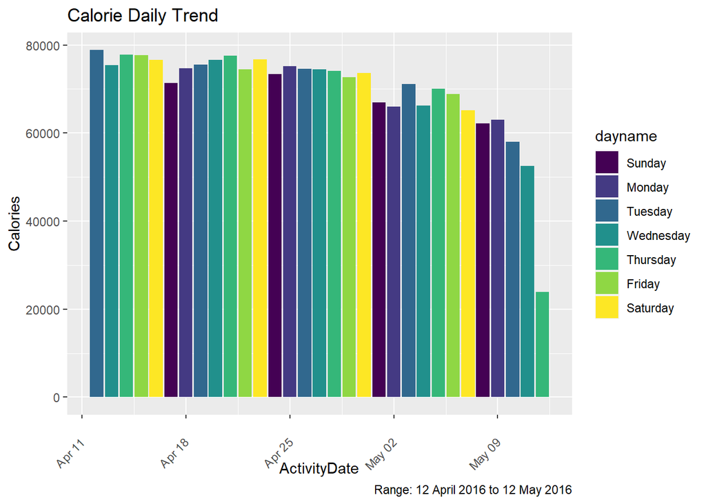

```r
activity_daily <- activity_daily %>%
  mutate(dayname = wday(ActivityDate, label = TRUE, abbr = FALSE),
         intensity_minutes = 0*SedentaryMinutes +
                       1*LightlyActiveMinutes +
                       2*FairlyActiveMinutes +
                       3*VeryActiveMinutes,
         intensity_distance = 0*SedentaryActiveDistance +
                         1*LightActiveDistance +
                         2*ModeratelyActiveDistance +
                         3*VeryActiveDistance)

ggplot(data = activity_daily, aes(x = ActivityDate, y = Calories, fill = dayname)) +
  geom_bar(stat = "identity") +
  theme(axis.text.x = element_text(angle = 45, vjust = 0.5, hjust = 1)) +
  labs(title = "Calorie Daily Trend",
       caption = "Range: 12 April 2016 to 12 May 2016")
```

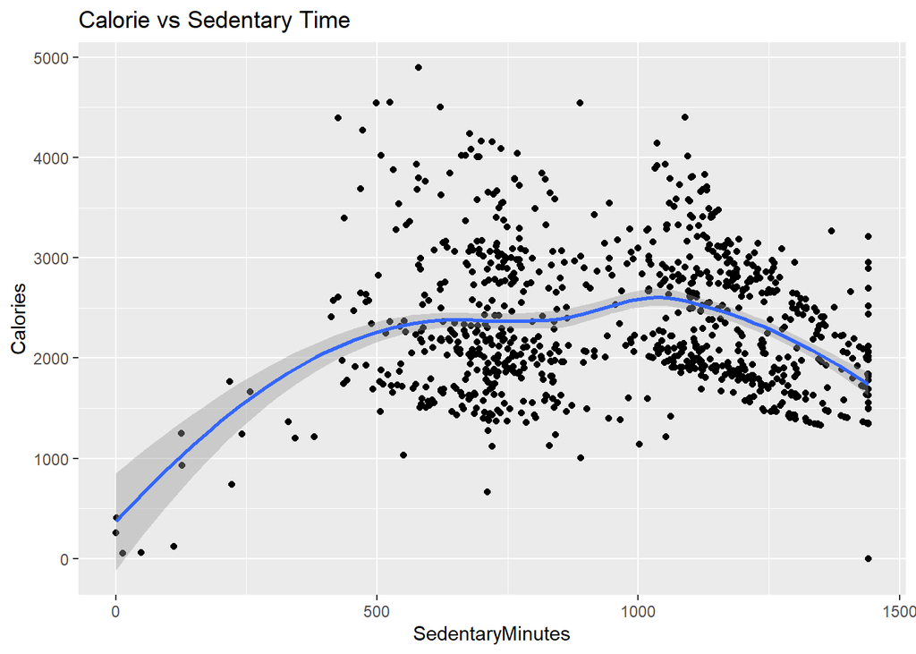

```r
ggplot(data = activity_daily, aes(x = SedentaryMinutes, y = Calories)) +
  geom_point() +
  geom_smooth() +
  labs(x = "SedentaryMinutes", y = "Calories",
       title = "Calorie vs Sedentary Time")
```

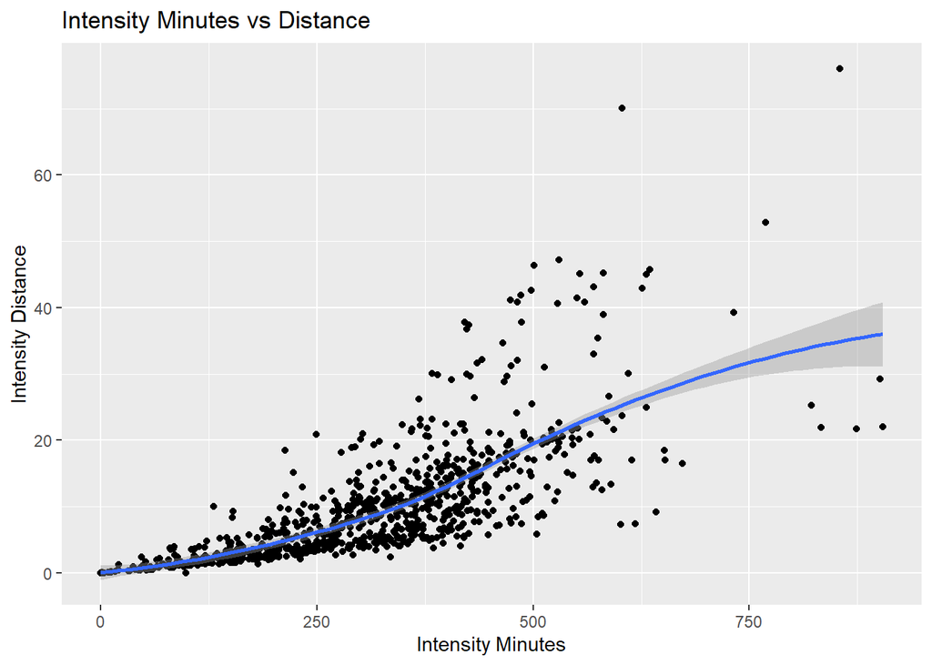

```r
ggplot(data = activity_daily, aes(x = intensity_minutes, y = intensity_distance)) +
  geom_point() +
  geom_smooth() +
  labs(x = "Intensity Minutes", y = "Intensity Distance",
       title="Intensity Minutes vs Distance")
```

We calculate the intensity of distance and minutes,  
we can see that the intensity time and distance have clear positive correlation.

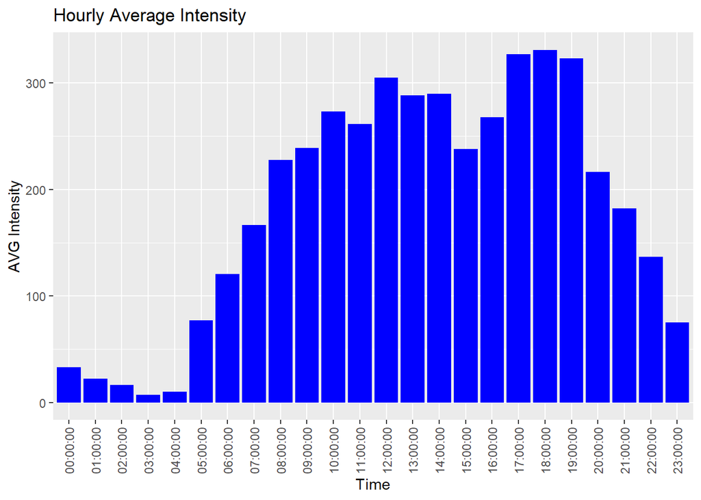

```r
ggplot(data = merged_hourly, aes(x = time)) +
  geom_bar(aes(y = AverageIntensity), fill = 'blue', stat = "identity") +
  theme(axis.text.x = element_text(angle = 90, vjust = 0.5, hjust = 1)) +
  labs(x = "Time", y = "AVG Intensity",
       title="Hourly Average Intensity")
```

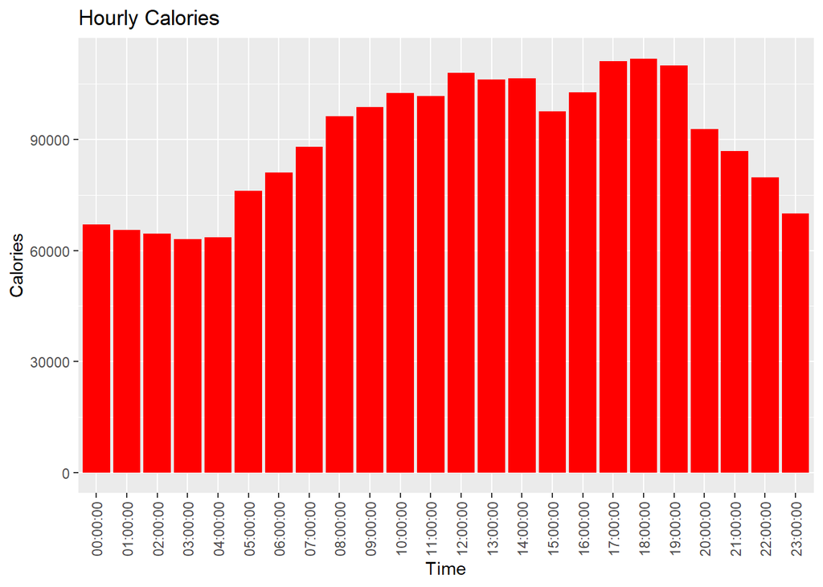

```r
ggplot(data = merged_hourly, aes(x = time)) +
  geom_bar(aes(y = Calories), fill = 'red', stat = "identity") +
  theme(axis.text.x = element_text(angle = 90, vjust = 0.5, hjust = 1)) +
  labs(x = "Time", y = "Calories",
       title="Hourly Calories")
```

Both chart shows daily pattern for calory burnt and average_intensity. intensity peaked at 17:00 to 19:00 as its a great time for workout.

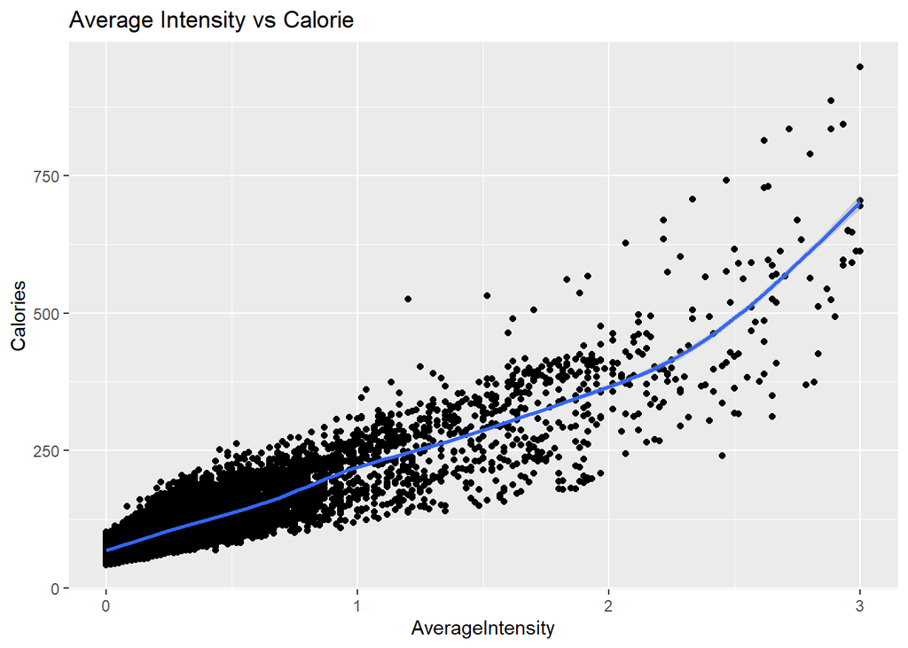

```r
ggplot(data = merged_hourly, aes(x = AverageIntensity, y = Calories)) +
  geom_point() +
  geom_smooth() +
  labs(x = "AverageIntensity", y = "Calories", title="Average Intensity vs Calorie")
```

This chart verifies the correlation of the amount of calories burnt and intensity.

```r
merged_daily <- merge(activity_daily, sleep_daily, by.x = c("Id", "ActivityDate"), by.y = c("Id", "SleepDate"))

head(merged_daily)
```

```
##           Id ActivityDate TotalSteps TotalDistance TrackerDistance
## 1 1503960366   2016-04-12      13162          8.50            8.50
## 2 1503960366   2016-04-13      10735          6.97            6.97
## 3 1503960366   2016-04-15       9762          6.28            6.28
## 4 1503960366   2016-04-16      12669          8.16            8.16
## 5 1503960366   2016-04-17       9705          6.48            6.48
## 6 1503960366   2016-04-19      15506          9.88            9.88
##   LoggedActivitiesDistance VeryActiveDistance ModeratelyActiveDistance
## 1                        0               1.88                     0.55
## 2                        0               1.57                     0.69
## 3                        0               2.14                     1.26
## 4                        0               2.71                     0.41
## 5                        0               3.19                     0.78
## 6                        0               3.53                     1.32
##   LightActiveDistance SedentaryActiveDistance VeryActiveMinutes
```

[output cut: 27 more lines]

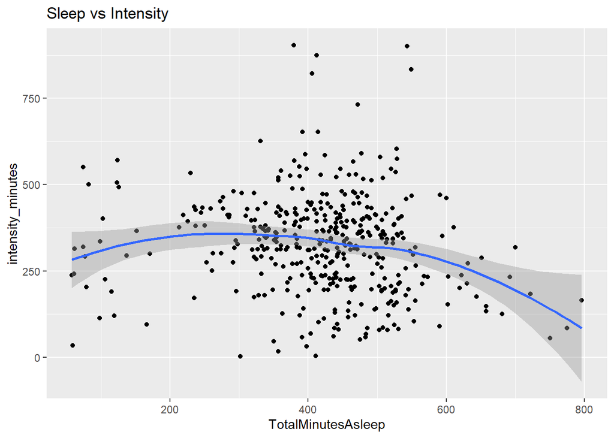

```r
ggplot(data = merged_daily, aes(x = TotalMinutesAsleep, y = intensity_minutes)) +
  geom_point() +
  geom_smooth() +
  labs(x = "TotalMinutesAsleep", y = "intensity_minutes", title="Sleep vs Intensity")
```

```r
head(weight_log)
```

```
## # A tibble: 6 × 11
##           Id Date       WeightKg WeightPounds   Fat   BMI IsManualReport   LogId
##        <dbl> <chr>         <dbl>        <dbl> <dbl> <dbl> <lgl>            <dbl>
## 1 1503960366 5/2/2016 …     52.6         116.    22  22.6 TRUE           1.46e12
## 2 1503960366 5/3/2016 …     52.6         116.    NA  22.6 TRUE           1.46e12
## 3 1927972279 4/13/2016…    134.          294.    NA  47.5 FALSE          1.46e12
## 4 2873212765 4/21/2016…     56.7         125.    NA  21.5 TRUE           1.46e12
## 5 2873212765 5/12/2016…     57.3         126.    NA  21.7 TRUE           1.46e12
## 6 4319703577 4/17/2016…     72.4         160.    25  27.5 TRUE           1.46e12
## # ℹ 3 more variables: Datetime <dttm>, date <date>, time <chr>
```

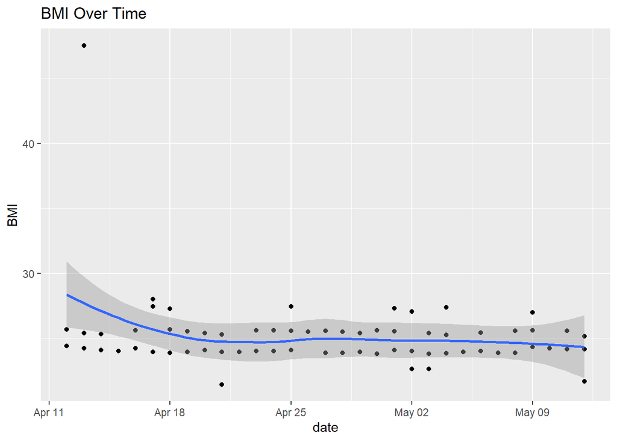

```r
ggplot(data=weight_log, aes(x=date, y=BMI)) +
  geom_point() +
  geom_smooth() +
  labs(title="BMI Over Time")
```

There are clear outliers in weight log that skew the plot but there are no significant difference in weights.